# Rapport — Segmentation client

Type : Rapport d'analyse Date : 15/06/2026 Statut : Confidentiel

# Segmentation client par Machine Learning

| **Module** | Machine Learning — Master 2 CDSD |
| --- | --- |
| **Auteur** | Steeve NGUEMA |

## Configuration de l'environnement

Chargement des librairies et des modules internes du projet.

```
Environnement prêt.
```

## 1. Chargement et description des données

### 1.1 Source des données

Le jeu de données est issu d'un CRM marketing. Il contient des informations socio-démographiques, les comportements d'achat, les canaux utilisés et les réponses aux campagnes de 2 240 clients. L'objectif est d'identifier des segments homogènes pour personnaliser les actions marketing.

```
Données chargées : 2,240 lignes x 29 colonnes
```

|  | ID | Year_Birth | Education | Marital_Status | Income | Kidhome | Teenhome | Dt_Customer | Recency | MntWines | ... | NumWebVisitsMonth | AcceptedCmp3 | AcceptedCmp4 | AcceptedCmp5 | AcceptedCmp1 | AcceptedCmp2 | Complain | Z_CostContact | Z_Revenue | Response |
| --- | --- | --- | --- | --- | --- | --- | --- | --- | --- | --- | --- | --- | --- | --- | --- | --- | --- | --- | --- | --- | --- |
| 0 | 5524 | 1957 | Graduation | Single | 58138.0 | 0 | 0 | 04/09/2012 | 58 | 635 | ... | 7 | 0 | 0 | 0 | 0 | 0 | 0 | 3 | 11 | 1 |
| 1 | 2174 | 1954 | Graduation | Single | 46344.0 | 1 | 1 | 08/03/2014 | 38 | 11 | ... | 5 | 0 | 0 | 0 | 0 | 0 | 0 | 3 | 11 | 0 |
| 2 | 4141 | 1965 | Graduation | Together | 71613.0 | 0 | 0 | 21/08/2013 | 26 | 426 | ... | 4 | 0 | 0 | 0 | 0 | 0 | 0 | 3 | 11 | 0 |
| 3 | 6182 | 1984 | Graduation | Together | 26646.0 | 1 | 0 | 10/02/2014 | 26 | 11 | ... | 6 | 0 | 0 | 0 | 0 | 0 | 0 | 3 | 11 | 0 |
| 4 | 5324 | 1981 | PhD | Married | 58293.0 | 1 | 0 | 19/01/2014 | 94 | 173 | ... | 5 | 0 | 0 | 0 | 0 | 0 | 0 | 3 | 11 | 0 |

5 rows × 29 columns

```
Types des variables :
ID                       int64
Year_Birth               int64
Education               object
Marital_Status          object
Income                 float64
Kidhome                  int64
Teenhome                 int64
Dt_Customer             object
Recency                  int64
MntWines                 int64
MntFruits                int64
MntMeatProducts          int64
MntFishProducts          int64
MntSweetProducts         int64
MntGoldProds             int64
NumDealsPurchases        int64
NumWebPurchases          int64
NumCatalogPurchases      int64
NumStorePurchases        int64
NumWebVisitsMonth        int64
AcceptedCmp3             int64
AcceptedCmp4             int64
AcceptedCmp5             int64
AcceptedCmp1             int64
AcceptedCmp2             int64
Complain                 int64
Z_CostContact            int64
Z_Revenue                int64
Response                 int64
dtype: object

Valeurs manquantes :
Income    24
dtype: int64
```

|  | ID | Year_Birth | Income | Kidhome | Teenhome | Recency | MntWines | MntFruits | MntMeatProducts | MntFishProducts | ... | NumWebVisitsMonth | AcceptedCmp3 | AcceptedCmp4 | AcceptedCmp5 | AcceptedCmp1 | AcceptedCmp2 | Complain | Z_CostContact | Z_Revenue | Response |
| --- | --- | --- | --- | --- | --- | --- | --- | --- | --- | --- | --- | --- | --- | --- | --- | --- | --- | --- | --- | --- | --- |
| count | 2240.000000 | 2240.000000 | 2216.000000 | 2240.000000 | 2240.000000 | 2240.000000 | 2240.000000 | 2240.000000 | 2240.000000 | 2240.000000 | ... | 2240.000000 | 2240.000000 | 2240.000000 | 2240.000000 | 2240.000000 | 2240.000000 | 2240.000000 | 2240.0 | 2240.0 | 2240.000000 |
| mean | 5592.159821 | 1968.805804 | 52247.251354 | 0.444196 | 0.506250 | 49.109375 | 303.935714 | 26.302232 | 166.950000 | 37.525446 | ... | 5.316518 | 0.072768 | 0.074554 | 0.072768 | 0.064286 | 0.013393 | 0.009375 | 3.0 | 11.0 | 0.149107 |
| std | 3246.662198 | 11.984069 | 25173.076661 | 0.538398 | 0.544538 | 28.962453 | 336.597393 | 39.773434 | 225.715373 | 54.628979 | ... | 2.426645 | 0.259813 | 0.262728 | 0.259813 | 0.245316 | 0.114976 | 0.096391 | 0.0 | 0.0 | 0.356274 |
| min | 0.000000 | 1893.000000 | 1730.000000 | 0.000000 | 0.000000 | 0.000000 | 0.000000 | 0.000000 | 0.000000 | 0.000000 | ... | 0.000000 | 0.000000 | 0.000000 | 0.000000 | 0.000000 | 0.000000 | 0.000000 | 3.0 | 11.0 | 0.000000 |
| 25% | 2828.250000 | 1959.000000 | 35303.000000 | 0.000000 | 0.000000 | 24.000000 | 23.750000 | 1.000000 | 16.000000 | 3.000000 | ... | 3.000000 | 0.000000 | 0.000000 | 0.000000 | 0.000000 | 0.000000 | 0.000000 | 3.0 | 11.0 | 0.000000 |
| 50% | 5458.500000 | 1970.000000 | 51381.500000 | 0.000000 | 0.000000 | 49.000000 | 173.500000 | 8.000000 | 67.000000 | 12.000000 | ... | 6.000000 | 0.000000 | 0.000000 | 0.000000 | 0.000000 | 0.000000 | 0.000000 | 3.0 | 11.0 | 0.000000 |
| 75% | 8427.750000 | 1977.000000 | 68522.000000 | 1.000000 | 1.000000 | 74.000000 | 504.250000 | 33.000000 | 232.000000 | 50.000000 | ... | 7.000000 | 0.000000 | 0.000000 | 0.000000 | 0.000000 | 0.000000 | 0.000000 | 3.0 | 11.0 | 0.000000 |
| max | 11191.000000 | 1996.000000 | 666666.000000 | 2.000000 | 2.000000 | 99.000000 | 1493.000000 | 199.000000 | 1725.000000 | 259.000000 | ... | 20.000000 | 1.000000 | 1.000000 | 1.000000 | 1.000000 | 1.000000 | 1.000000 | 3.0 | 11.0 | 1.000000 |

8 rows × 26 columns

**Observations** : Le jeu de données contient 2 240 clients et 29 variables. Seule la variable `Income` présente 24 valeurs manquantes (∼ 1 %), qui seront imputées par la médiane. Les colonnes `Z_CostContact` et `Z_Revenue` sont constantes (3 et 11) et seront supprimées. `ID` et `Dt_Customer` ne portent aucune information utile au clustering.

## 2. Analyse Exploratoire des Données (EDA)

L'EDA vise à comprendre les profils clients avant tout prétraitement, afin d'orienter le choix des features et d'interpréter les clusters a posteriori.

### 2.1 Profils démographiques

On analyse l'âge (calculé depuis `Year_Birth`), le revenu (`Income`) et la situation familiale (`Marital_Status`, `Kidhome`, `Teenhome`).

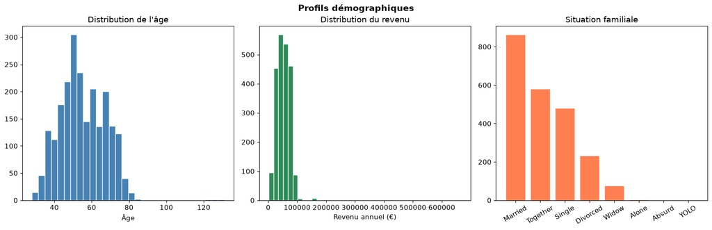

**Observation** : La majorité des clients ont entre 35 et 65 ans. Le revenu suit une distribution quasi-normale avec quelques valeurs extrêmes (jusqu'à 666 666 €). Les clients mariés ou en couple représentent la majorité, ce qui influencera la présence d'enfants au foyer.

### 2.2 Comportements d'achat — Dépenses par catégorie

On analyse la répartition des dépenses entre les 6 catégories de produits.

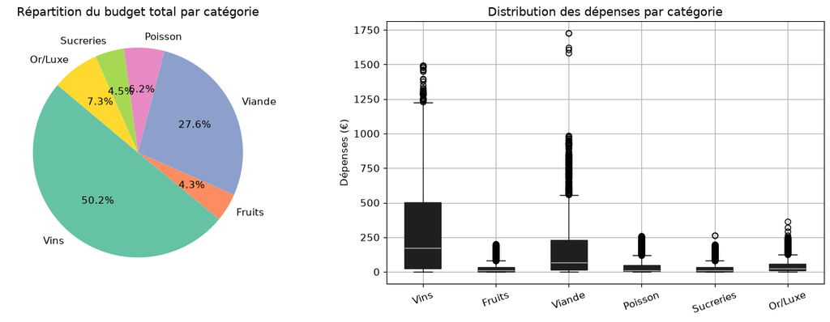

**Observation** : Les vins représentent près de 50 % du budget total des clients, suivis des produits carnés. Les autres catégories sont minoritaires. Les boxplots révèlent une forte variabilité intra-catégorie et de nombreux outliers, confirmant l'hétérogénéité des profils clients.

### 2.3 Canaux d'achat

On compare l'utilisation des quatre canaux : promotions, web, catalogue, magasin.

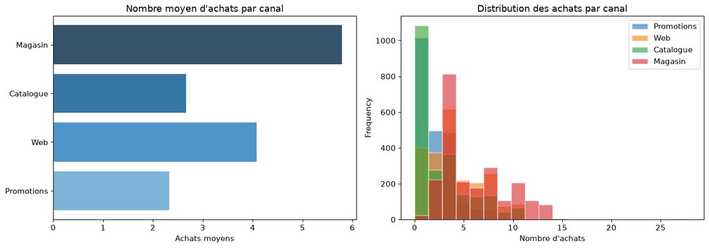

**Observation** : Le magasin physique reste le canal dominant, suivi du web. Les achats via catalogue révèlent un segment plus premium. Les promotions attirent une clientèle sensible aux prix.

### 2.4 Réponses aux campagnes marketing

Les 5 campagnes passées et la réponse à la dernière campagne permettent d'identifier les clients les plus réceptifs.

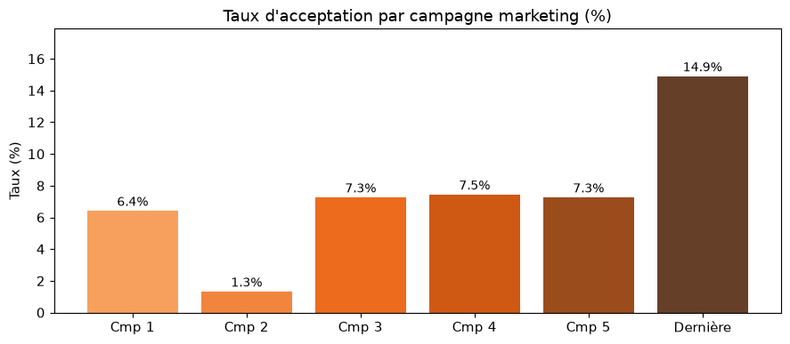

### 2.5 Matrice de corrélation

La heatmap révèle les redondances entre variables et guide la sélection des features.

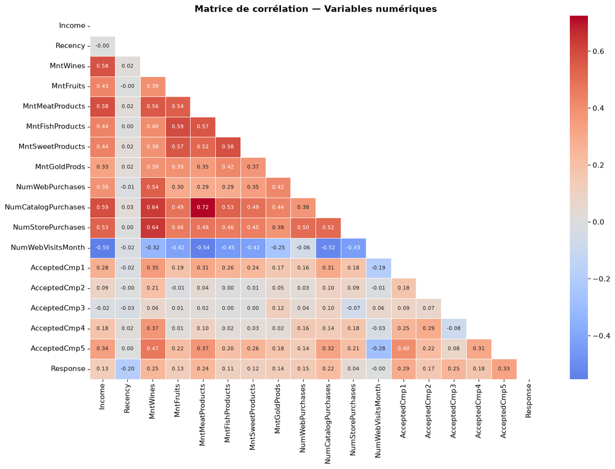

**Observation** : Les dépenses par catégorie sont fortement corrélées entre elles (clients qui dépensent beaucoup tendent à le faire sur toutes les catégories). Le revenu (`Income`) est positivement corrélé aux dépenses totales. La variable `Recency` est quasi-indépendante des autres, ce qui en fait un discriminant potentiel.

## 3. Prétraitement

Le prétraitement suit les étapes suivantes :

1. Imputation des valeurs manquantes (`Income`)
2. Feature engineering (variables synthétiques)
3. Encodage des variables catégorielles
4. Sélection des features de clustering
5. Normalisation (`StandardScaler`)
6. PCA pour visualisation 2D

### 3.1 Imputation des valeurs manquantes

Les 24 valeurs manquantes de `Income` sont imputées par la **médiane**, plus robuste que la moyenne face aux valeurs extrêmes.

```
Valeurs manquantes Income avant : 24
Valeurs manquantes Income après : 0
Médiane utilisée : 51,382 €
```

### 3.2 Feature Engineering

Cinq variables synthétiques sont créées pour résumer l'information :

| Variable | Définition | Raison |
| --- | --- | --- |
| `Age` | `2024 - Year_Birth` | Plus interprétable que l'année de naissance |
| `TotalSpent` | Somme des 6 catégories de dépenses | Capture le budget global |
| `TotalPurchases` | Somme des 4 canaux d'achat | Volume d'activité |
| `HasChildren` | 1 si Kidhome + Teenhome > 0 | Contrainte familiale |
| `TotalCampaignes` | Somme des 6 acceptations campagnes | Réceptivité marketing |

```
Features créées : Age, TotalSpent, TotalPurchases, HasChildren, TotalCampaignes
```

|  | Age | TotalSpent | TotalPurchases | HasChildren | TotalCampaignes |
| --- | --- | --- | --- | --- | --- |
| count | 2240.000000 | 2240.000000 | 2240.000000 | 2240.000000 | 2240.000000 |
| mean | 55.194196 | 605.798214 | 14.862054 | 0.715179 | 0.446875 |
| std | 11.984069 | 602.249288 | 7.677173 | 0.451430 | 0.890543 |
| min | 28.000000 | 5.000000 | 0.000000 | 0.000000 | 0.000000 |
| 25% | 47.000000 | 68.750000 | 8.000000 | 0.000000 | 0.000000 |
| 50% | 54.000000 | 396.000000 | 15.000000 | 1.000000 | 0.000000 |
| 75% | 65.000000 | 1045.500000 | 21.000000 | 1.000000 | 1.000000 |
| max | 131.000000 | 2525.000000 | 44.000000 | 1.000000 | 5.000000 |

### 3.3 Encodage des variables catégorielles

- `Education` : encodage ordinal (Basic=0, 2n Cycle=1, Graduation=2, Master=3, PhD=4)
- `Marital_Status` : regroupement (Alone/Absurd/YOLO → Single), puis binaire (seul=0, séparé/veuf=1, en couple=2)

```
Encodage terminé.
Education : {2: 1127, 4: 486, 3: 370, 1: 203, 0: 54}
Marital_Status : {2: 1444, 0: 487, 1: 309}
```

### 3.4 Sélection des features de clustering

On conserve 11 features représentatives. Les colonnes redondantes (détail par catégorie remplacé par les agrégats), les colonnes constantes (`Z_CostContact`, `Z_Revenue`) et les identifiants (`ID`, `Dt_Customer`) sont écartés.

```
Dimensions du dataset de clustering : (2240, 11)
Features retenues : ['Age', 'Income', 'Education', 'Marital_Status', 'HasChildren', 'Recency', 'TotalSpent', 'TotalPurchases', 'NumWebVisitsMonth', 'TotalCampaignes', 'Complain']
```

### 3.5 Normalisation (StandardScaler)

K-Means et les autres algorithmes basés sur des distances sont **sensibles aux échelles**. Le `StandardScaler` ramène chaque variable à une moyenne de 0 et un écart-type de 1.

```
Dimensions après normalisation : (2240, 11)
Moyenne des features (doit être ~0) : [-0. -0.  0.  0. -0. -0.  0. -0. -0.  0. -0.]
```

### 3.6 Réduction dimensionnelle — PCA (visualisation)

La PCA est utilisée **uniquement pour la visualisation 2D** des clusters. Le clustering lui-même s'effectue sur l'espace complet à 11 dimensions.

```
Variance expliquée — PC1 : 29.5%, PC2 : 11.3%
Variance totale expliquée : 40.8%
```

**Synthèse prétraitement** : Le jeu de données est désormais normalisé, enrichi de 5 variables synthétiques et réduit à 11 features discriminantes.

## 4. Modélisation — Clustering

Quatre algorithmes de clustering sont comparés. Contrairement à la classification supervisée, aucun label n'est disponible : les métriques d'évaluation sont intrinsèques (Silhouette Score, Davies-Bouldin). Chaque run est tracé dans MLflow.

```
2026/06/15 21:56:43 INFO mlflow.tracking.fluent: Experiment with name 'segmentation_client' does not exist. Creating a new experiment.
```

```
Expérience MLflow initialisée.
```

### 4.1 Choix du nombre de clusters — Méthode Elbow + Silhouette

Avant d'entraîner K-Means, on détermine le nombre optimal de clusters `k` grâce à deux critères complémentaires :

- **Méthode Elbow** : inertie (somme des distances intra-cluster)
- **Silhouette Score** : cohésion intra-cluster vs séparation inter-cluster (max = 1)

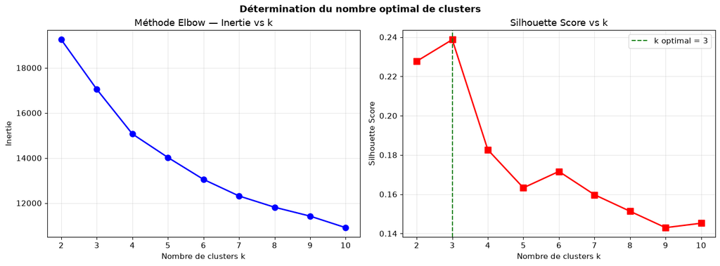

```
Nombre optimal de clusters : k = 3 (Silhouette = 0.2387)
```

**Observation** : Le coude de l'inertie et le pic du Silhouette Score convergent vers un nombre optimal de clusters. Ce `k` est utilisé pour tous les algorithmes afin de faciliter la comparaison des métriques.

### 4.2 K-Means

[output not shown]

```
Silhouette Score : 0.2387
Davies-Bouldin Score : 1.3135
Run K-Means terminé.
```

### 4.3 DBSCAN

DBSCAN est un algorithme basé sur la densité. Il détecte automatiquement les outliers (label -1) sans nécessiter de préciser le nombre de clusters.

[output not shown]

### 4.4 Clustering Agglomératif (Hierarchical)

```
Silhouette Score : 0.2116
Davies-Bouldin Score : 1.3862
Run Agglomératif terminé.
```

### 4.5 Gaussian Mixture Models (GMM)

Le GMM modélise les clusters comme des distributions gaussiennes multivariées. Il permet des frontières de clusters souples (soft assignments) et capture mieux des formes elliptiques.

```
Silhouette Score : 0.2384
Davies-Bouldin Score : 1.4744
Run GMM terminé.
```

## 5. Évaluation et comparaison des algorithmes

### 5.1 Tableau comparatif des métriques

Deux métriques intrinsèques sont comparées :

- **Silhouette Score** : entre -1 et 1, plus élevé = meilleur
- **Davies-Bouldin Score** : plus faible = meilleur (clusters compacts et bien séparés)

```
=== Comparaison des algorithmes de clustering ===
              Silhouette Score  Davies-Bouldin Score
Algorithme
DBSCAN                  0.4135                0.7092
K-Means                 0.2387                1.3135
GMM                     0.2384                1.4744
Agglomératif            0.2116                1.3862

Meilleur algorithme : DBSCAN
```

### 5.2 Visualisation des clusters en 2D (PCA)

Les clusters obtenus par le meilleur algorithme sont projetés sur les 2 premières composantes principales pour une visualisation intuitive.

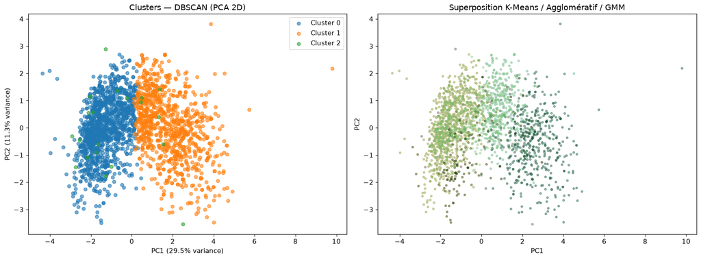

## 6. Interprétation métier des clusters

On utilise les labels du meilleur algorithme pour analyser les profils moyens de chaque cluster et leur attribuer un nom métier.

```
=== Profils moyens par cluster ===
           Age    Income  Education  Marital_Status  HasChildren  Recency  TotalSpent  TotalPurchases  NumWebVisitsMonth  TotalCampaignes  Complain
Cluster
0        53.53  37934.13       2.36            1.42         0.90    49.05      176.54           10.03               6.48             0.19       0.0
1        57.40  72038.02       2.61            1.43         0.46    49.11     1200.44           21.54               3.71             0.81       0.0
2        58.90  45242.29       2.00            1.33         0.81    53.05      376.43           13.24               5.81             0.29       1.0
```

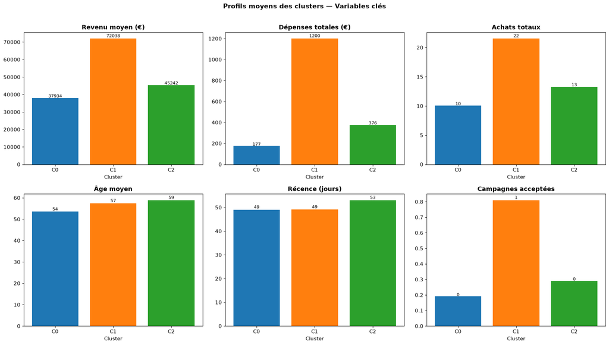

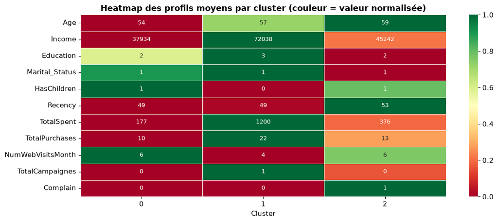

### 6.1 Attribution des noms métier

Sur la base des profils moyens, chaque cluster reçoit un **label métier** :

[output not shown]

> *Note : les numéros de clusters peuvent varier à chaque exécution — vérifier les profils pour confirmer l'attribution.*

```
Mapping clusters → noms métier :
  Cluster 1 → Premium
  Cluster 2 → Digital
  Cluster 0 → Promo-Sensible

Répartition des segments :
Segment
Promo-Sensible    1284
Premium            935
Digital             21
Name: count, dtype: int64
```

## 7. Recommandations business

### 7.1 Stratégies par segment

[output not shown]

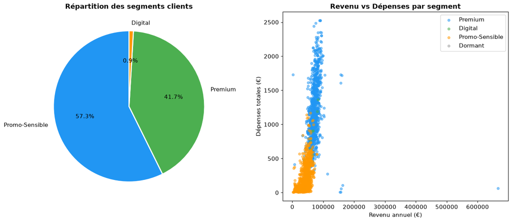

```
=== Tableau récapitulatif des segments ===
                   N  Revenu_Moyen  Depenses_Moyennes  Age_Moyen  Campagnes_Moyennes     %
Segment
Digital           21       45242.3              376.4       58.9                 0.3   0.9
Premium          935       72038.0             1200.4       57.4                 0.8  41.7
Promo-Sensible  1284       37934.1              176.5       53.5                 0.2  57.3
```

### 7.2 Bilan technique

[output not shown]

### 7.3 Limites et améliorations possibles

- **Période** : le comportement d'achat évolue — actualiser la segmentation tous les 6 mois
- **Variables manquantes** : intégrer les données comportementales en temps réel (clics, sessions)
- **DBSCAN** : les hyperparamètres `eps` et `min_samples` nécessitent une optimisation fine
- **Validation externe** : taux de conversion par segment pour valider la pertinence métier

```
Modèle sauvegardé : ../donnees/traitees/kmeans_segmentation.pkl
Modèle de segmentation sauvegardé.
```

15/06/2026 | Usage interne — Diffusion restreinte